# R Notebook for additional analysis for Fig. 1 (v2)

With Wan-hsuan, starting from 2023 Oct

## [1] Experimental protocols

### [1.1] Sampling locations and dates

#### [1.1.1] Locations

1. Stn.Ie-1 in the north basin of Lake Biwa: Ie-1 35°12’58”N 135°59’55”E
2. Yasu river: 35°02’35.5”N 136°01’10.0”E
3. Hino river: 35°06’09.1”N 136°04’37.4”E
4. Echi river: 35°11’44.0”N 136°10’46.5”E
5. Ane river: 35°24’45.1”N 136°16’59.0”E

##### [1.1.2] Dates

1. Lake Biwa: 2019/07/03, 07/30, 09/10, 10/17
2. Four rivers: 2019/07/09, 08/07, 09/17, 10/15

### [1.2] Sampling methods

#### [1.2.1] Collection of prokaryotic DNA: Filtering Water

- STERIVEX-GV 0.22UM PVDF

## [2] Bioinformatics/modeling protocols

### [2.0] Generating Fastq files without demultiplexing (bcl2fastq v2.18)

### [2.1] Tag and Primer Filtering and Demultiplex by claident (version v0.2.2018.05.29)

### [2.2] dada2 for ASV composition

### [2.3] PiCRUSt2 for KO composition for each ASV

## [3] Loading and summarizing data

### [3.0] Loading packages

```r
library(vegan)
library(ggeffects)
library(ggplot2)
library(parallel)
```

### [3.1] Loading data

#### [3.1.1] Loading sample information for Miseq

```r
sample_info <- read.csv("SampleSheet_RMR152.csv", skip = 19, header = T)
sample_info
```

| Sample_ID | Sample_Name | Sample_Plate | Sample_Well | I7_Index_ID | index | I5_Index_ID | index2 | Sample_Project | Description |
| --- | --- | --- | --- | --- | --- | --- | --- | --- | --- |
| RMR-152-Miki-S001 | s001 | NA | NA | D701 | ATTACTCG | D501 | TATAGCCT | MikiBiwaBacDNA | 20190703_biwa |
| RMR-152-Miki-S002 | s002 | NA | NA | D702 | TCCGGAGA | D501 | TATAGCCT | MikiBiwaBacDNA | 20190709_ane |
| RMR-152-Miki-S003 | s003 | NA | NA | D703 | CGCTCATT | D501 | TATAGCCT | MikiBiwaBacDNA | 20190709_echi |
| RMR-152-Miki-S004 | s004 | NA | NA | D704 | GAGATTCC | D501 | TATAGCCT | MikiBiwaBacDNA | 20190709_hino |
| RMR-152-Miki-S005 | s005 | NA | NA | D705 | ATTCAGAA | D501 | TATAGCCT | MikiBiwaBacDNA | 20190709_yasu |
| RMR-152-Miki-S006 | s006 | NA | NA | D706 | GAATTCGT | D501 | TATAGCCT | MikiBiwaBacDNA | 20190730_biwa |
| RMR-152-Miki-S007 | s007 | NA | NA | D707 | CTGAAGCT | D501 | TATAGCCT | MikiBiwaBacDNA | 20190807_ane |
| RMR-152-Miki-S008 | s008 | NA | NA | D708 | TAATGCGC | D501 | TATAGCCT | MikiBiwaBacDNA | 20190807_echi |
| RMR-152-Miki-S009 | s009 | NA | NA | D701 | ATTACTCG | D502 | ATAGAGGC | MikiBiwaBacDNA | 20190807_hino |
| RMR-152-Miki-S010 | s010 | NA | NA | D702 | TCCGGAGA | D502 | ATAGAGGC | MikiBiwaBacDNA | 20190807_yasu |

[output cut: 12 more lines]

#### [3.1.2] Bacterial direct count

```r
#loading data
raw_bac_count <- read.csv("bacterial_count_sumitomo.csv", header = T)
raw_bac_count
```

| month | river | count01 | count02 | count03 | count04 | count05 | count06 | count07 | count08 | count09 | count10 |
| --- | --- | --- | --- | --- | --- | --- | --- | --- | --- | --- | --- |
| 07_July | biwa | 223 | 147 | 175 | 182 | 123 | 168 | 118 | 191 | 144 | 167 |
| 07_July | ane | 46 | 31 | 51 | 49 | 32 | 43 | 28 | 65 | 71 | 35 |
| 07_July | echi | 34 | 23 | 31 | 24 | 11 | 16 | 34 | 18 | 13 | 43 |
| 07_July | hino | 136 | 110 | 126 | 152 | 83 | 101 | 154 | 119 | 105 | 184 |
| 07_July | yasu | 66 | 50 | 53 | 88 | 124 | 103 | 83 | 58 | 90 | 43 |
| 08_Aug | biwa | 83 | 88 | 124 | 117 | 158 | 119 | 182 | 155 | 165 | 184 |
| 08_Aug | ane | 45 | 26 | 31 | 35 | 52 | 29 | 40 | 19 | 35 | 36 |
| 08_Aug | echi | 59 | 60 | 55 | 53 | 47 | 47 | 39 | 41 | 75 | 27 |
| 08_Aug | hino | 168 | 196 | 185 | 145 | 163 | 164 | 196 | 186 | 177 | 162 |
| 08_Aug | yasu | 148 | 109 | 81 | 128 | 120 | 114 | 146 | 110 | 123 | 94 |

[output cut: 10 more lines]

```r
#calculating the averages of ten repetitions for each example
average <- apply(raw_bac_count[3:12], 1, mean)
#converting the averaged raw count to cell density (cells/mL) using conversion factors
A <- 210 #effective filtered area (mm^2)
G <- 77*77*1.0e-6 #area of one vision (mm^2)
V <- 1.0  #volume of filtered sample (ml)
cell_density <- average*(A/G)/V
#integrating into the dataframe
bac_cell_density <- data.frame(month = raw_bac_count$month, location = raw_bac_count$river, average_count = average, density = cell_density)
bac_cell_density
```

| month | location | average_count | density |
| --- | --- | --- | --- |
| 07_July | biwa | 163.8 | 5801652.9 |
| 07_July | ane | 45.1 | 1597402.6 |
| 07_July | echi | 24.7 | 874852.4 |
| 07_July | hino | 127.0 | 4498229.0 |
| 07_July | yasu | 75.8 | 2684769.8 |
| 08_Aug | biwa | 137.5 | 4870129.9 |
| 08_Aug | ane | 34.8 | 1232585.6 |
| 08_Aug | echi | 50.3 | 1781582.1 |
| 08_Aug | hino | 174.2 | 6170011.8 |
| 08_Aug | yasu | 117.3 | 4154663.5 |

[output cut: 10 more lines]

```r
saveRDS(bac_cell_density, "bac_cell_density.obj")
```

#### [3.1.3] Ecoplate-based Multifunctionality = Phenotypic Multifunctionality (MF_P)

```r
MF_P <- readRDS("./Jan2024v3/MF_list/MF_integ14_ave_matrix_raw.obj")
head(MF_P)
```

```
              Sample_1 Sample_2 Sample_3 Sample_4 Sample_5 Sample_6 Sample_7 Sample_8 Sample_9
treshold_0          21       29       30       30       30       15       31       30       30
treshold_0.05       18       29       29       30       30       10       31       30       30
treshold_0.1        17       29       29       30       29        8       31       30       30
treshold_0.15       16       29       28       30       29        5       31       28       30
treshold_0.2        16       29       28       29       29        4       29       28       30
treshold_0.25       13       29       27       29       29        2       28       27       30
              Sample_10 Sample_11 Sample_12 Sample_13 Sample_14 Sample_15 Sample_16 Sample_17
treshold_0           28        22        30        31        30        29        30        30
treshold_0.05        28        13        30        30        29        27        30        30
treshold_0.1         26        10        30        30        29        27        30        30
treshold_0.15        26         5        30        30        28        26        30        30
treshold_0.2         26         3        30        29        28        21        28        30
treshold_0.25        24         2        30        29        28        17        25        30
              Sample_18 Sample_19 Sample_20
treshold_0           28        30        30
treshold_0.05        28        30        30
treshold_0.1         28        30        30
treshold_0.15        28        30        30
treshold_0.2         28        30        30
treshold_0.25        28        30        30
```

#### [3.1.4] Compiled sample info, before coverage-based standardization

List of ASV composition before coverage-based standardization but ASVs from mitochondria and chloroplas excluded

```r
raw_prokaryote_ASVcomposition_info <- as.data.frame( readRDS("./Jan2024v3/ASV_composition/table_ASV_no-mitochondria-no-chloroplas_biwako_dada2_Jan2024.obj"))

#The number of ASVs that were detected in two negative samples
apply(raw_prokaryote_ASVcomposition_info > 0, 1, sum)[21:22]
```

```
s021_prokaryote.forward.fastq s022_prokaryote.forward.fastq
                           12                             7
```

```r
#The total reads that were detected in two negative samples
apply(raw_prokaryote_ASVcomposition_info, 1, sum)[21:22]
```

```
s021_prokaryote.forward.fastq s022_prokaryote.forward.fastq
                           29                            16
```

List of sample (data set) info, bacterial abundance, sampling coverage (cov_exclu), #reads (seq_exclu), #observed ASVs (rich_exclu)

```r
attributes_sample <- readRDS("./Jan2024v3/attri_exclu_undeter.eukar_Jan2024.obj")
attributes_sample$sample_ID <- c("S01", "S02", "S03", "S04", "S05", "S06", "S07", "S08", "S09", "S10", "S11", "S12", "S13", "S14", "S15", "S16", "S17", "S18", "S19", "S20")
attributes_sample[, -c(4,5)]
```

| sample_ID | date_sample | location | abs_abundance | cov_exclu | seq_exclu | rich_exclu |
| --- | --- | --- | --- | --- | --- | --- |
| S01 | 20190703 | Biwa | 5801652.9 | 0.9958 | 36070 | 611 |
| S02 | 20190709 | Ane | 1597402.6 | 0.9691 | 22232 | 2642 |
| S03 | 20190709 | Echi | 874852.4 | 0.9733 | 22494 | 2551 |
| S04 | 20190709 | Hino | 4498229.0 | 0.9775 | 32067 | 2415 |
| S05 | 20190709 | Yasu | 2684769.8 | 0.9790 | 36297 | 2088 |
| S06 | 20190730 | Biwa | 4870129.9 | 0.9954 | 38549 | 675 |
| S07 | 20190807 | Ane | 1232585.6 | 0.9835 | 35879 | 2793 |
| S08 | 20190807 | Echi | 1781582.1 | 0.9551 | 15907 | 2016 |
| S09 | 20190807 | Hino | 6170011.8 | 0.7805 | 815 | 262 |
| S10 | 20190807 | Yasu | 4154663.5 | 0.7975 | 434 | 140 |

[output cut: 10 more lines]

#### [3.1.5] ASV composition table

ASV table being rarefied with the coverage = 0.9232 and then ASVs with 1) poor alignment to PiCRUST2 or 2) with 0 abundance being deleted, noting that the data sets with low coverages were also excluded and 13 data sets remained.

```r
remaining_ID <- c("S01", "S02", "S03", "S04", "S05", "S06", "S07", "S08", "S11", "S17", "S18", "S19", "S20")
stand_ASV_com <- readRDS("./Jan2024v3/ASV_composition/Com_rarefied_exclu_undeter.eukar_AfterNeg_filtered_order_del0ASV_Jan2024.obj")
class(stand_ASV_com)
```

```
[1] "data.frame"
```

```r
colnames(stand_ASV_com)
```

```
 [1] "Sample_1"  "Sample_2"  "Sample_3"  "Sample_4"  "Sample_5"  "Sample_6"  "Sample_7"
 [8] "Sample_8"  "Sample_11" "Sample_17" "Sample_18" "Sample_19" "Sample_20"
```

```r
colnames(stand_ASV_com) <- remaining_ID
head(stand_ASV_com[, 2:5])
```

|  | S02 | S03 | S04 | S05 |
| --- | --- | --- | --- | --- |
| AACCAGCACCTCAAGTGGTCAGGAGGATTATTGGGCCTAAAGCATCCGTAGCCGGTTCTG…… | 0.51 | 1.88 | 0.30 | 0.87 |
| AACCAGCACCTCAAGTGGTCAGGAGGATTATTGGGCCTAAAGCATCCGTAGCCGGTTCTG…… | 0.99 | 0.00 | 0.00 | 0.00 |
| AACCAGCACCTCAAGTGGTCAGGATGATTATTGGGCCTAAAGCATCCGTAGCTCGTTTTG…… | 6.19 | 12.26 | 1.75 | 3.63 |
| AACCAGCACCTCAAGTGGTCAGGATGATTATTGGGCCTAAAGCATCCGTAGCTCGTTTTG…… | 13.32 | 16.89 | 3.65 | 3.97 |
| AACCAGCACCTCGAGTGGTCAGGAGGTTTATTGGGCCTAAAGCATCCGTAGCCGGCTGCT…… | 1.03 | 0.94 | 0.25 | 0.23 |
| AACCAGCACCTCGAGTGGTCAGGAGGTTTATTGGGCCTAAAGCATCCGTAGCCGGTTGCA…… | 1.86 | 3.57 | 1.25 | 1.09 |

#### [3.1.6] KO composition table for each ASV that was included in “stand_ASV_com”.

```r
KO_com <- readRDS("./Jan2024v3/KO_composition/KO_exclu_undeter.eukar_AfterNeg_filtered_order_del0ASV_Jan2024.obj")
class(KO_com)
```

```
[1] "data.frame"
```

```r
head(KO_com)
```

|  | K00001 | K00002 | K00003 | K00004 | K00005 | K00006 | K00007 | K00008 | K00009 | K00010 | K00011 | K00012 | K00013 | K00014 | K00015 | K00016 | K00018 | K00019 | K00020 | K00021 | K00022 | K00023 | K00024 | K00025 | K00026 | K00027 | K00028 | K00029 | K00030 | … |
| --- | --- | --- | --- | --- | --- | --- | --- | --- | --- | --- | --- | --- | --- | --- | --- | --- | --- | --- | --- | --- | --- | --- | --- | --- | --- | --- | --- | --- | --- | --- |
| AACCAGCACCTCAAGTGGTCAGGAGGATTATTGGGCCTAAAGCATCCGTAGCCGGTTCTG…… | 0 | 0 | 1 | 0 | 0 | 0 | 0 | 1 | 0 | 0 | 0 | 0 | 1 | 1 | 1 | 0 | 0 | 0 | 1 | 0 | 0 | 0 | 2 | 0 | 0 | 0 | 0 | 0 | 0 | … |
| AACCAGCACCTCAAGTGGTCAGGAGGATTATTGGGCCTAAAGCATCCGTAGCCGGTTCTG…… | 0 | 0 | 1 | 0 | 0 | 0 | 0 | 1 | 0 | 0 | 0 | 1 | 1 | 1 | 1 | 0 | 0 | 0 | 1 | 0 | 0 | 0 | 1 | 0 | 0 | 0 | 0 | 0 | 0 | … |
| AACCAGCACCTCAAGTGGTCAGGATGATTATTGGGCCTAAAGCATCCGTAGCTCGTTTTG…… | 0 | 0 | 1 | 0 | 0 | 0 | 0 | 1 | 0 | 0 | 0 | 0 | 1 | 1 | 1 | 0 | 0 | 0 | 1 | 0 | 0 | 0 | 2 | 0 | 0 | 0 | 0 | 0 | 0 | … |
| AACCAGCACCTCAAGTGGTCAGGATGATTATTGGGCCTAAAGCATCCGTAGCTCGTTTTG…… | 0 | 0 | 1 | 0 | 0 | 0 | 0 | 1 | 0 | 0 | 0 | 0 | 1 | 1 | 1 | 0 | 0 | 0 | 2 | 0 | 0 | 0 | 2 | 0 | 0 | 0 | 0 | 0 | 0 | … |
| AACCAGCACCTCGAGTGGTCAGGAGGTTTATTGGGCCTAAAGCATCCGTAGCCGGCTGCT…… | 0 | 0 | 1 | 0 | 0 | 0 | 0 | 1 | 0 | 0 | 0 | 0 | 1 | 1 | 1 | 0 | 0 | 0 | 1 | 0 | 0 | 0 | 2 | 0 | 0 | 0 | 0 | 0 | 0 | … |
| AACCAGCACCTCGAGTGGTCAGGAGGTTTATTGGGCCTAAAGCATCCGTAGCCGGTTGCA…… | 0 | 0 | 1 | 0 | 0 | 0 | 0 | 1 | 0 | 0 | 0 | 0 | 1 | 1 | 1 | 0 | 0 | 0 | 1 | 0 | 0 | 0 | 2 | 0 | 0 | 0 | 0 | 0 | 0 | … |

### [3.2] Data conversion

#### [3.2.1] Binarization

Binarization of ASV composition with the threshold 0.0 for ASVs and 1 for KOs

```r
#copy
stand_ASV_com_binarized <- stand_ASV_com
KO_com_binarized <- KO_com

#binarized
stand_ASV_com_binarized[stand_ASV_com_binarized > 0] <- 1.0
stand_ASV_com_binarized[stand_ASV_com_binarized < 0] <- 0.0

KO_com_binarized[KO_com_binarized >= 1.0] <- 1.0
KO_com_binarized[KO_com_binarized < 1.0] <- 0.0
```

#### [3.2.2] Calculating richness

ASV and KO richness for the whole dat sets

```r
ASV_gamma_richness <- sum(apply(stand_ASV_com_binarized, 1, sum) > 0)
KO_gamma_richness <- sum(apply(KO_com_binarized, 2, sum) > 0)
ASV_gamma_richness
```

```
[1] 3576
```

```r
KO_gamma_richness
```

```
[1] 7340
```

ASV and KO richness for each data set

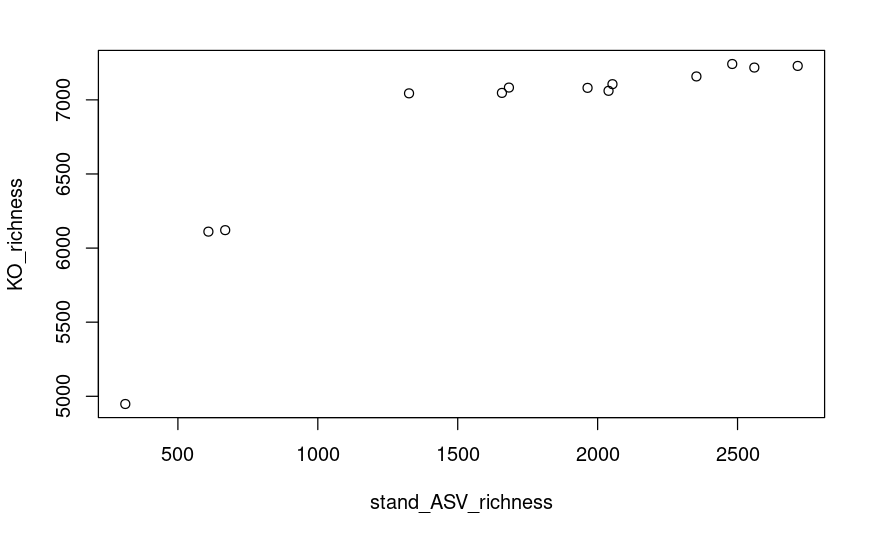

```r
stand_ASV_richness <- apply(stand_ASV_com_binarized, 2, sum)
KO_richness <- numeric(13)
for(j in 1:13) {
  #Obtain the KO composition for each data set
  KO_list <- t(KO_com_binarized) %*% stand_ASV_com_binarized[, j]
  #Calculate the number of KOs
  KO_richness[j] <- sum(KO_list > 0)
}
MF_P_filtered0.05 <- MF_P[2, c(1,2,3,4,5,6,7,8,11,17,18,19,20)] #subsets of samples that are remaining for further bioinformatic analyses
plot(stand_ASV_richness, KO_richness)
```

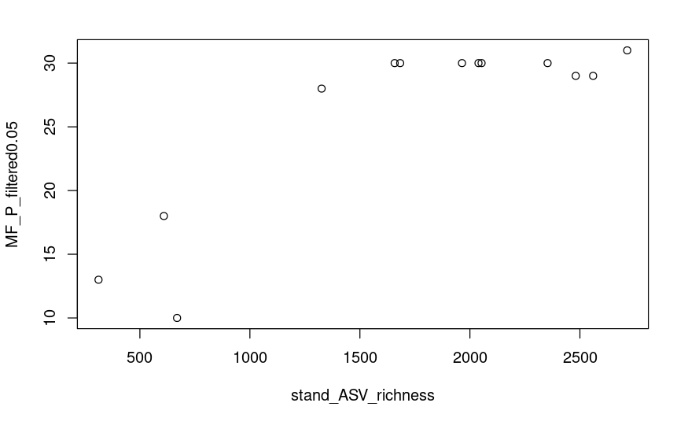

```r
plot(stand_ASV_richness, MF_P_filtered0.05)
```

### [3.3] Summary of data sets

Summarizing basic info into a dataframe

```r
richness_temp <- data.frame(sample_ID = remaining_ID, stand_ASV_richness, KO_richness)
data_summary <- merge(attributes_sample[, -c(4,5)], richness_temp, by = "sample_ID", all = T)
colnames(data_summary)[4:7] <- c("bacterial abundance", "coverage", "no_reads", "obs_ASV_richness")
data_summary <- data.frame(data_summary, MF_P0.05 = MF_P[2, ])
data_summary
```

|  | sample_ID | date_sample | location | bacterial.abundance | coverage | no_reads | obs_ASV_richness | stand_ASV_richness | KO_richness | MF_P0.05 |
| --- | --- | --- | --- | --- | --- | --- | --- | --- | --- | --- |
| Sample_1 | S01 | 20190703 | Biwa | 5801652.9 | 0.9958 | 36070 | 611 | 609 | 6111 | 18 |
| Sample_2 | S02 | 20190709 | Ane | 1597402.6 | 0.9691 | 22232 | 2642 | 2560 | 7218 | 29 |
| Sample_3 | S03 | 20190709 | Echi | 874852.4 | 0.9733 | 22494 | 2551 | 2481 | 7242 | 29 |
| Sample_4 | S04 | 20190709 | Hino | 4498229.0 | 0.9775 | 32067 | 2415 | 2353 | 7158 | 30 |
| Sample_5 | S05 | 20190709 | Yasu | 2684769.8 | 0.9790 | 36297 | 2088 | 2039 | 7061 | 30 |
| Sample_6 | S06 | 20190730 | Biwa | 4870129.9 | 0.9954 | 38549 | 675 | 669 | 6121 | 10 |
| Sample_7 | S07 | 20190807 | Ane | 1232585.6 | 0.9835 | 35879 | 2793 | 2715 | 7229 | 31 |
| Sample_8 | S08 | 20190807 | Echi | 1781582.1 | 0.9551 | 15907 | 2016 | 1964 | 7081 | 30 |
| Sample_9 | S09 | 20190807 | Hino | 6170011.8 | 0.7805 | 815 | 262 | NA | NA | 30 |
| Sample_10 | S10 | 20190807 | Yasu | 4154663.5 | 0.7975 | 434 | 140 | NA | NA | 28 |

[output cut: 10 more lines]

### [3.3.1] (Revision for Freshw Biol) Addition MF_P with different thresholds

```r
data_summary <- data.frame(data_summary, MF_P0.10 = MF_P[3, ], MF_P0.15 = MF_P[4, ], MF_P0.20 = MF_P[5, ])
data_summary
```

|  | sample_ID | date_sample | location | bacterial.abundance | coverage | no_reads | obs_ASV_richness | stand_ASV_richness | KO_richness | MF_P0.05 | MF_P0.10 | MF_P0.15 | MF_P0.20 |
| --- | --- | --- | --- | --- | --- | --- | --- | --- | --- | --- | --- | --- | --- |
| Sample_1 | S01 | 20190703 | Biwa | 5801652.9 | 0.9958 | 36070 | 611 | 609 | 6111 | 18 | 17 | 16 | 16 |
| Sample_2 | S02 | 20190709 | Ane | 1597402.6 | 0.9691 | 22232 | 2642 | 2560 | 7218 | 29 | 29 | 29 | 29 |
| Sample_3 | S03 | 20190709 | Echi | 874852.4 | 0.9733 | 22494 | 2551 | 2481 | 7242 | 29 | 29 | 28 | 28 |
| Sample_4 | S04 | 20190709 | Hino | 4498229.0 | 0.9775 | 32067 | 2415 | 2353 | 7158 | 30 | 30 | 30 | 29 |
| Sample_5 | S05 | 20190709 | Yasu | 2684769.8 | 0.9790 | 36297 | 2088 | 2039 | 7061 | 30 | 29 | 29 | 29 |
| Sample_6 | S06 | 20190730 | Biwa | 4870129.9 | 0.9954 | 38549 | 675 | 669 | 6121 | 10 | 8 | 5 | 4 |
| Sample_7 | S07 | 20190807 | Ane | 1232585.6 | 0.9835 | 35879 | 2793 | 2715 | 7229 | 31 | 31 | 31 | 29 |
| Sample_8 | S08 | 20190807 | Echi | 1781582.1 | 0.9551 | 15907 | 2016 | 1964 | 7081 | 30 | 30 | 28 | 28 |
| Sample_9 | S09 | 20190807 | Hino | 6170011.8 | 0.7805 | 815 | 262 | NA | NA | 30 | 30 | 30 | 30 |
| Sample_10 | S10 | 20190807 | Yasu | 4154663.5 | 0.7975 | 434 | 140 | NA | NA | 28 | 26 | 26 | 26 |

[output cut: 10 more lines]

## [4] Relationship between ASV richness, KO richness, and Ecoplate Multifunctionality

### [4.1] Data prearrangement

```r
richness_MF <- data.frame(ASV_richness = stand_ASV_richness, MF_G = KO_richness, MF_P0.05 = MF_P_filtered0.05, location = data_summary$location[c(1,2,3,4,5,6,7,8,11,17,18,19,20)], date = data_summary$date_sample[c(1,2,3,4,5,6,7,8,11,17,18,19,20)])

richness_MF
```

|  | ASV_richness | MF_G | MF_P0.05 | location | date |
| --- | --- | --- | --- | --- | --- |
| S01 | 609 | 6111 | 18 | Biwa | 20190703 |
| S02 | 2560 | 7218 | 29 | Ane | 20190709 |
| S03 | 2481 | 7242 | 29 | Echi | 20190709 |
| S04 | 2353 | 7158 | 30 | Hino | 20190709 |
| S05 | 2039 | 7061 | 30 | Yasu | 20190709 |
| S06 | 669 | 6121 | 10 | Biwa | 20190730 |
| S07 | 2715 | 7229 | 31 | Ane | 20190807 |
| S08 | 1964 | 7081 | 30 | Echi | 20190807 |
| S11 | 312 | 4948 | 13 | Biwa | 20190910 |
| S17 | 2053 | 7106 | 30 | Ane | 20191015 |

[output cut: 3 more lines]

### [4.2] Basic plotting

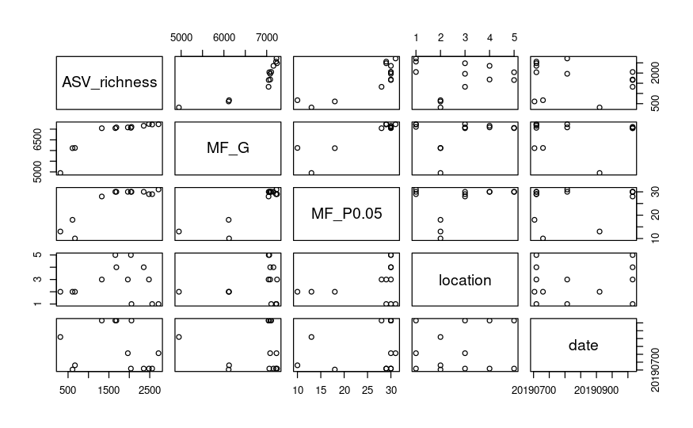

```r
plot(richness_MF)
```

### [4.3] linear model

```r
lm_model <- lm(MF_P0.05 ~ MF_G, data = richness_MF)
summary(lm_model)
```

```
Call:
lm(formula = MF_P0.05 ~ MF_G, data = richness_MF)

Residuals:
    Min      1Q  Median      3Q     Max
-9.4562 -0.9701  0.9245  1.3430  4.7861

Coefficients:
              Estimate Std. Error t value Pr(>|t|)
(Intercept) -39.208828   9.942854  -3.943   0.0023 **
MF_G          0.009584   0.001455   6.588 3.93e-05 ***
---
Signif. codes:  0 ‘***’ 0.001 ‘**’ 0.01 ‘*’ 0.05 ‘.’ 0.1 ‘ ’ 1

Residual standard error: 3.408 on 11 degrees of freedom
Multiple R-squared:  0.7978,    Adjusted R-squared:  0.7794
F-statistic:  43.4 on 1 and 11 DF,  p-value: 3.926e-05
```

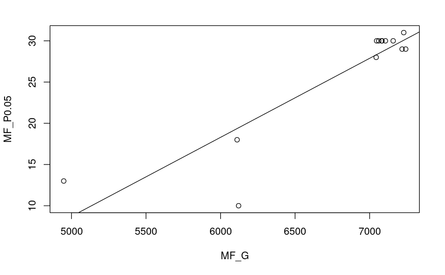

```r
plot(MF_P0.05 ~ MF_G, data = richness_MF)
abline(lm_model)
```

```r
#glm and stepwise model selection
summary(step(glm(MF_P0.05 ~ MF_G + ASV_richness, data = richness_MF, family = poisson(link = "log"))))
```

```
Start:  AIC=77.07
MF_P0.05 ~ MF_G + ASV_richness

               Df Deviance    AIC
- ASV_richness  1   5.5179 75.171
<none>              5.4150 77.068
- MF_G          1  10.0893 79.742

Step:  AIC=75.17
MF_P0.05 ~ MF_G

       Df Deviance    AIC
<none>      5.5179 75.171
- MF_G  1  28.8685 96.522

Call:
glm(formula = MF_P0.05 ~ MF_G, family = poisson(link = "log"),
    data = richness_MF)

Deviance Residuals:
     Min        1Q    Median        3Q       Max
-2.00659  -0.01277   0.07949   0.26200   0.93343

Coefficients:
              Estimate Std. Error z value Pr(>|z|)
(Intercept) -0.1612495  0.8031090  -0.201    0.841
MF_G         0.0004963  0.0001151   4.311 1.63e-05 ***
---
Signif. codes:  0 ‘***’ 0.001 ‘**’ 0.01 ‘*’ 0.05 ‘.’ 0.1 ‘ ’ 1

(Dispersion parameter for poisson family taken to be 1)

    Null deviance: 28.8685  on 12  degrees of freedom
Residual deviance:  5.5179  on 11  degrees of freedom
AIC: 75.171

Number of Fisher Scoring iterations: 4
```

```r
#best
z <- glm(MF_P0.05 ~ MF_G, data = richness_MF, family = poisson(link = "log"))
```

#### [4.3.1] Figure 1

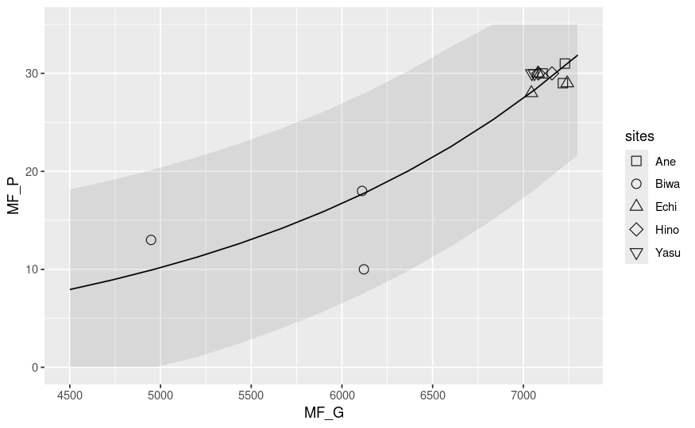

```r
y_max <- 35
richness_MF$mf_g = seq(4500, 7300, length.out = 13)
richness_MF$predicted = exp(z$coefficients[1] + z$coefficients[2] * richness_MF$mf_g)
richness_MF$Low = richness_MF$predicted - 2 * sqrt(mean(richness_MF$MF_P0.05))
richness_MF$Low[richness_MF$Low < 0] <- 0
richness_MF$High = richness_MF$predicted + 2 * sqrt(mean(richness_MF$MF_P0.05))
richness_MF$High[richness_MF$High > y_max] <- y_max

linear_plot <- ggplot(data = richness_MF) + geom_point(aes(x = MF_G, y = MF_P0.05, shape = location), size = 3, alpha = 0.9) + labs(shape = "sites") + scale_shape_manual(values = c(0, 1, 2, 5, 6))
linear_plot <- linear_plot + geom_line(aes(x = mf_g, y = predicted))
linear_plot <- linear_plot + geom_ribbon(aes(x = mf_g, ymin = Low, ymax = High), alpha = 0.1)
linear_plot <- linear_plot + xlab("MF_G") + ylab("MF_P") + ylim(0, y_max)
plot(linear_plot)
```

#### [4.3.2] Figure 1 (Revison for Freshw Biol)

Subset of the data exclusing Biwa

```r
richness_MF_river <- subset(richness_MF, location != "Biwa")
richness_MF_river
```

|  | ASV_richness | MF_G | MF_P0.05 | location | date | mf_g | predicted | Low | High |
| --- | --- | --- | --- | --- | --- | --- | --- | --- | --- |
| S02 | 2560 | 7218 | 29 | Ane | 20190709 | 4733.333 | 8.916076 | 0.000000 | 19.11412 |
| S03 | 2481 | 7242 | 29 | Echi | 20190709 | 4966.667 | 10.010724 | 0.000000 | 20.20876 |
| S04 | 2353 | 7158 | 30 | Hino | 20190709 | 5200.000 | 11.239765 | 1.041726 | 21.43780 |
| S05 | 2039 | 7061 | 30 | Yasu | 20190709 | 5433.333 | 12.619698 | 2.421659 | 22.81774 |
| S07 | 2715 | 7229 | 31 | Ane | 20190807 | 5900.000 | 15.908616 | 5.710577 | 26.10666 |
| S08 | 1964 | 7081 | 30 | Echi | 20190807 | 6133.333 | 17.861755 | 7.663716 | 28.05979 |
| S17 | 2053 | 7106 | 30 | Ane | 20191015 | 6600.000 | 22.516847 | 12.318808 | 32.71489 |
| S18 | 1326 | 7044 | 28 | Echi | 20191015 | 6833.333 | 25.281294 | 15.083255 | 35.00000 |
| S19 | 1683 | 7083 | 30 | Hino | 20191015 | 7066.667 | 28.385139 | 18.187100 | 35.00000 |
| S20 | 1658 | 7047 | 30 | Yasu | 20191015 | 7300.000 | 31.870050 | 21.672011 | 35.00000 |

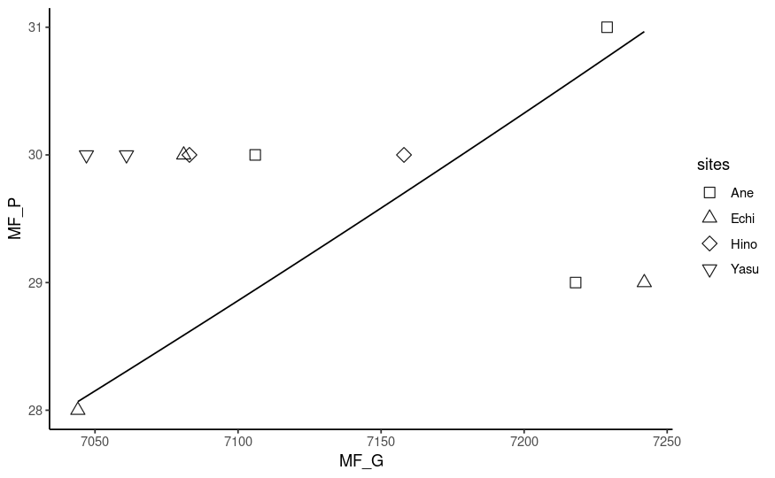

```r
linear_plot2 <- ggplot(data = richness_MF_river) + geom_point(aes(x = MF_G, y = MF_P0.05, shape = location), size = 3, alpha = 0.9) + labs(shape = "sites") + scale_shape_manual(values = c(0, 2, 5, 6))
linear_plot2 <- linear_plot2 +　stat_function(fun = function(x) exp(z$coefficients[1] + z$coefficients[2] * x))
linear_plot2 <- linear_plot2 + xlab("MF_G") + ylab("MF_P")
#linear_plot2 <- linear_plot2 + theme(panel.background = element_rect(fill = "transparent", colour = "black"),panel.grid = element_blank())
linear_plot2 <- linear_plot2 + theme_classic()
plot(linear_plot2)
```